# Actividad 2.3 Regresión lineal múltiple

Lucero Díaz

2026-10-04

## 1. Análisis exploratorio

```r
library(car)
library(lmtest)
```

```r
library(plot3D)
```

```r
# Carga del dataset
datos <- read.csv("C:/Users/ludio/Downloads/datosRes-1 (3).csv")
```

### Gráficos de dispersión entre variables.

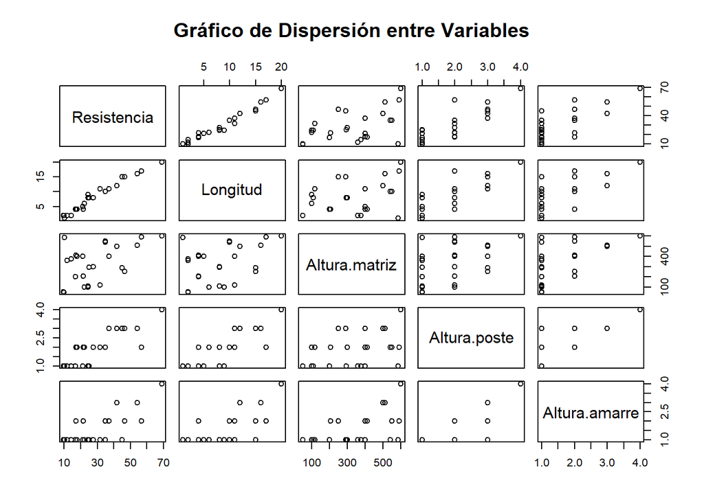

```r
# Matriz de dispersión completa
pairs(datos, main = "Gráfico de Dispersión entre Variables")
```

### Matriz de correlación de los datos

```r
# Matriz de correlación
cor_X = cor(datos)
cat("Matriz de correlación: \n")
```

```
## Matriz de correlación:
```

```r
print(cor_X)
```

```
##               Resistencia  Longitud Altura.matriz Altura.poste Altura.amarre
## Resistencia     1.0000000 0.9818118     0.4928666    0.8356493     0.7483815
## Longitud        0.9818118 1.0000000     0.3784127    0.7950203     0.6560819
## Altura.matriz   0.4928666 0.3784127     1.0000000    0.4243451     0.5377305
## Altura.poste    0.8356493 0.7950203     0.4243451    1.0000000     0.7793701
## Altura.amarre   0.7483815 0.6560819     0.5377305    0.7793701     1.0000000
```

Podemos observar como hay una correlación positiva fuerte entre varios pares de variables (>0.7): Altura amarre y Resistencia, Altura amarre y Altura poste, Longitud y Altura poste, Altura poste y Resistencia, y finalmente Longitud y Resistencia (correlación positiva más fuerte con ~0.98, cercana a 1).

### Gráficos de boxplot/histogramas

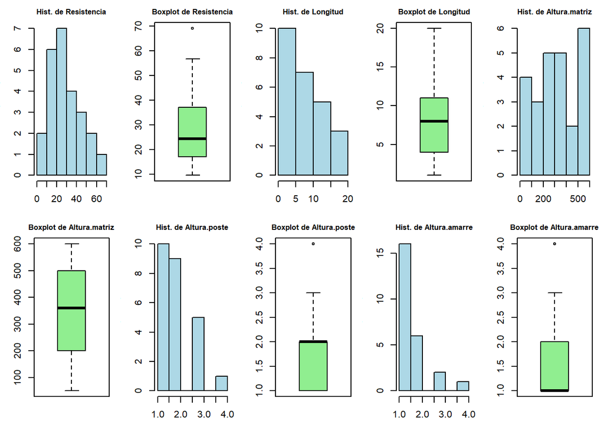

```r
par(mfrow = c(2, ncol(datos)), mar = c(3, 3, 2, 1))
for (col in colnames(datos)) {
  hist(datos[[col]], main = paste("Hist. de", col), xlab = col, col = "lightblue", cex.main = 0.8)
  boxplot(datos[[col]], main = paste("Boxplot de", col), col = "lightgreen", cex.main = 0.8)
}
```

```r
par(mfrow = c(1, 1))
```

Podemos observar que la mayoría de las variables parecen tener sesgo a la derecha por lo que vemos en los histogramas y en los boxplots, al también presentarse datos atípicos extremadamente positivos. La única excepción es la variable Altura matriz, donde su boxplot muestra que la distrubución de los datos parece simétrica y su histograma no parece mostrar un sesgo a la derecha o izquierda notable.

## 2. Método de mínimos cuadrados

El método de mínimos cuadrados para regresión lineal múltiple utiliza el vector de coeficientes $\hat{\boldsymbol{\beta}}$, donde la fórmula correspondiente es:

$$\hat{\boldsymbol{\beta}} = (\mathbf{X}^T
\mathbf{X})^{-1} \mathbf{X}^T \mathbf{Y}$$

```r
Y <- datos$Resistencia
X <- as.matrix(cbind(Intercepto = 1, datos[, c("Longitud", "Altura.matriz", "Altura.poste", "Altura.amarre")]))

# Fórmula matricial
beta_mco <- solve(t(X) %*% X) %*% t(X) %*% Y
cat("Coeficientes calculados por mínimos cuadrados \n")
```

```
## Coeficientes calculados por mínimos cuadrados
```

```r
print(beta_mco)
```

```
##                      [,1]
## Intercepto    1.068134045
## Longitud      2.484232443
## Altura.matriz 0.008553692
## Altura.poste  0.622369141
## Altura.amarre 2.293923555
```

La ecuación que describe el modelo de regresión lineal múltiple planteado es:

$$\hat{Y} = 1.068134045 + 2.484232443
\times Longitud + 0.008553692 \times Altura.matriz + 0.622369141 \times
Altura.poste + 2.293923555 \times Altura.amarre$$

## 3. Regresión lineal múltiple en R

```r
modelo_r <- lm(Resistencia ~ Longitud + Altura.matriz + Altura.poste + Altura.amarre, data = datos)

summary(modelo_r)
```

```
##
## Call:
## lm(formula = Resistencia ~ Longitud + Altura.matriz + Altura.poste +
##     Altura.amarre, data = datos)
##
## Residuals:
##     Min      1Q  Median      3Q     Max
## -3.2818 -1.2098 -0.0752  1.2279  3.0588
##
## Coefficients:
##               Estimate Std. Error t value Pr(>|t|)
## (Intercept)   1.068134   0.927733   1.151  0.26317
## Longitud      2.484232   0.110073  22.569 1.06e-15 ***
## Altura.matriz 0.008554   0.002359   3.626  0.00168 **
## Altura.poste  0.622369   0.811020   0.767  0.45181
## Altura.amarre 2.293924   0.748549   3.064  0.00612 **
## ---
## Signif. codes:  0 '***' 0.001 '**' 0.01 '*' 0.05 '.' 0.1 ' ' 1
##
## Residual standard error: 1.755 on 20 degrees of freedom
## Multiple R-squared:  0.9899, Adjusted R-squared:  0.9879
## F-statistic: 490.6 on 4 and 20 DF,  p-value: < 2.2e-16
```

```r
comparacion <- cbind(MC_Matricial = beta_mco[, 1], lm_r = coef(modelo_r))
cat("Comparación mínimos cuadrados vs lm() \n")
```

```
## Comparación mínimos cuadrados vs lm()
```

```r
print(comparacion)
```

```
##               MC_Matricial        lm_r
## Intercepto     1.068134045 1.068134045
## Longitud       2.484232443 2.484232443
## Altura.matriz  0.008553692 0.008553692
## Altura.poste   0.622369141 0.622369141
## Altura.amarre  2.293923555 2.293923555
```

Graficaremos en 3 dimensiones para observar la dispersión entre la variable dependiente (Resistencia) y las dos variables que tienen una mayor correlación positiva con esta variable (Longitud y Altura poste).

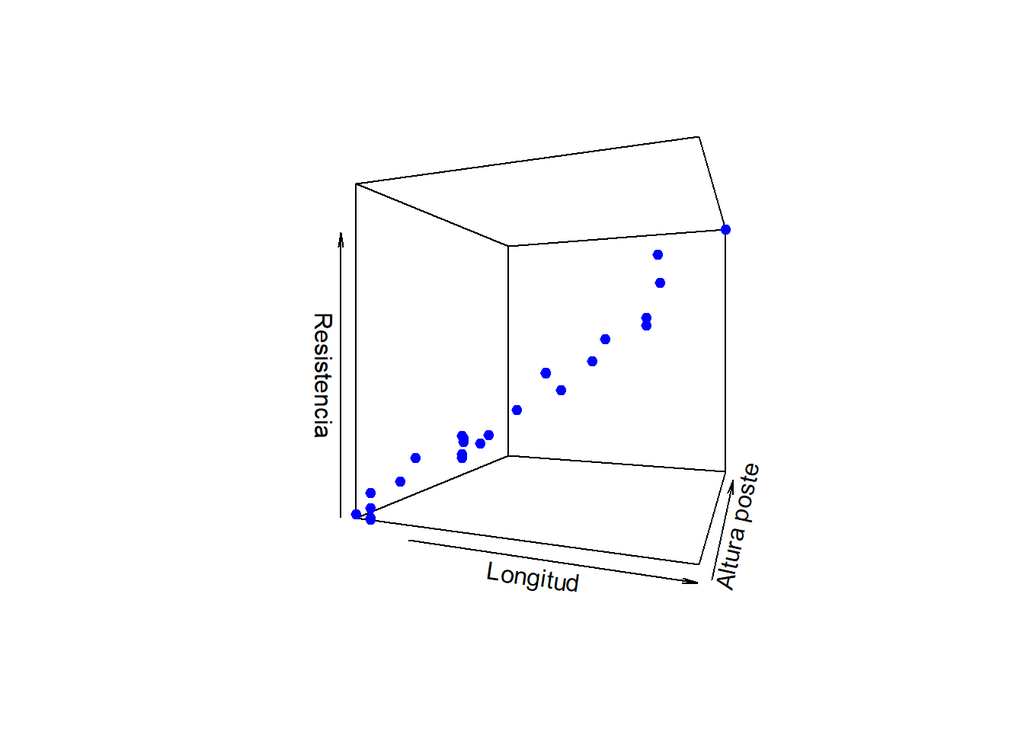

```r
scatter3D(x = datos$Longitud, y = datos$Altura.poste, z = datos$Resistencia, col="blue", cex = 0.9 , pch=19, xlab= "Longitud", ylab= "Altura poste", zlab= "Resistencia",phi=0, theta=20)
```

## 4. Evaluación del modelo

Utilizaremos el modelo proporcionado con la función de R, puesto que es el óptimo computacionalmente y el que debe estar más acercado a cómo se describe la variable dependiente con base a las demás variables.

### Colinealidad de las variables involucradas

Para verificar la colinealidad/multicolinealidad entre variables, se utiliza el Factor de Inflación de la Varianza ($\text{VIF}$). Un valor VIF mayor a 5 o 10 indica una multicolinealidad problemática entre las variables.

```r
cat("Factor de Inflación de la Varianza (VIF) \n")
```

```
## Factor de Inflación de la Varianza (VIF)
```

```r
print(vif(modelo_r))
```

```
##      Longitud Altura.matriz  Altura.poste Altura.amarre
##      2.748118      1.409504      3.980888      2.954590
```

Por lo que se observa en los resultados, no se observa una colinealidad problemática entre las variables.

```r
summary(modelo_r)
```

```
##
## Call:
## lm(formula = Resistencia ~ Longitud + Altura.matriz + Altura.poste +
##     Altura.amarre, data = datos)
##
## Residuals:
##     Min      1Q  Median      3Q     Max
## -3.2818 -1.2098 -0.0752  1.2279  3.0588
##
## Coefficients:
##               Estimate Std. Error t value Pr(>|t|)
## (Intercept)   1.068134   0.927733   1.151  0.26317
## Longitud      2.484232   0.110073  22.569 1.06e-15 ***
## Altura.matriz 0.008554   0.002359   3.626  0.00168 **
## Altura.poste  0.622369   0.811020   0.767  0.45181
## Altura.amarre 2.293924   0.748549   3.064  0.00612 **
## ---
## Signif. codes:  0 '***' 0.001 '**' 0.01 '*' 0.05 '.' 0.1 ' ' 1
##
## Residual standard error: 1.755 on 20 degrees of freedom
## Multiple R-squared:  0.9899, Adjusted R-squared:  0.9879
## F-statistic: 490.6 on 4 and 20 DF,  p-value: < 2.2e-16
```

### Variabilidad explicada por el modelo (coeficiente de determinación)

El coeficiente de determinación ($R^2$) indica un 98.99% de variabilidad explicada por el modelo, lo cual es un indicio muy bueno del rendimiento de este mismo.

### Significancia del modelo: Valor p del modelo (F)

Como el p-value de la prueba F del modeo es prácticamente 0 (2.2e-16), podemos afirmar que las variables en conjunto explican de manera significativa a la variable dependiente.

Todas las variables son estadísticamente significativas para el modelo, a excepción de la variable Altura poste, donde su p-value supera el nivel de significancia de 0.05.

### Economía del modelo y variabilidad explicada (Coeficiente de determinación)

Dado que Altura poste no es significativa ($p > 0.05$), se puede evaluar un modelo simplificado (parsimonioso) excluyendo dicha variable sin perder capacidad explicativa.

## 5. Validación del modelo

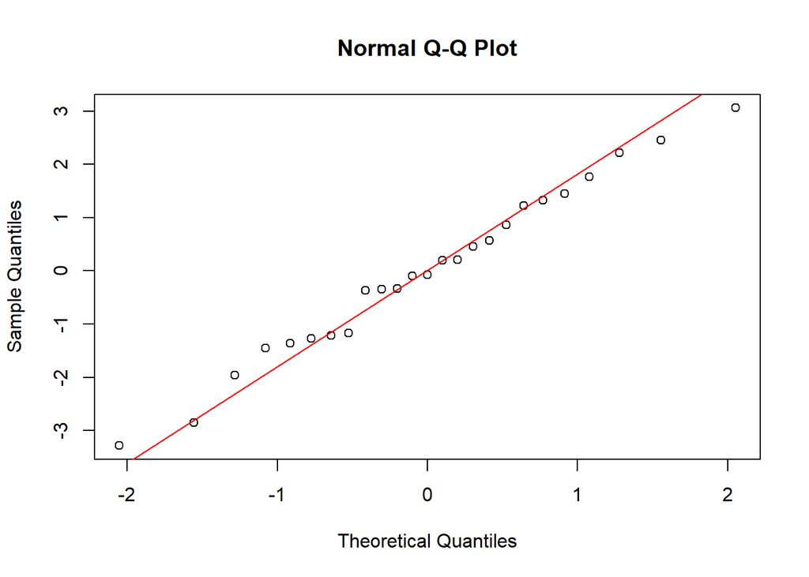

```r
residuos <- residuals(modelo_r)
ajustados <- fitted(modelo_r)

qqnorm(residuos); qqline(residuos, col = "red")
```

```r
shapiro.test(residuos)
```

```
##
##  Shapiro-Wilk normality test
##
## data:  residuos
## W = 0.98639, p-value = 0.9766
```

```r
t.test(residuos)
```

```
##
##  One Sample t-test
##
## data:  residuos
## t = 5.1266e-16, df = 24, p-value = 1
## alternative hypothesis: true mean is not equal to 0
## 95 percent confidence interval:
##  -0.6612908  0.6612908
## sample estimates:
##   mean of x
## 1.64261e-16
```

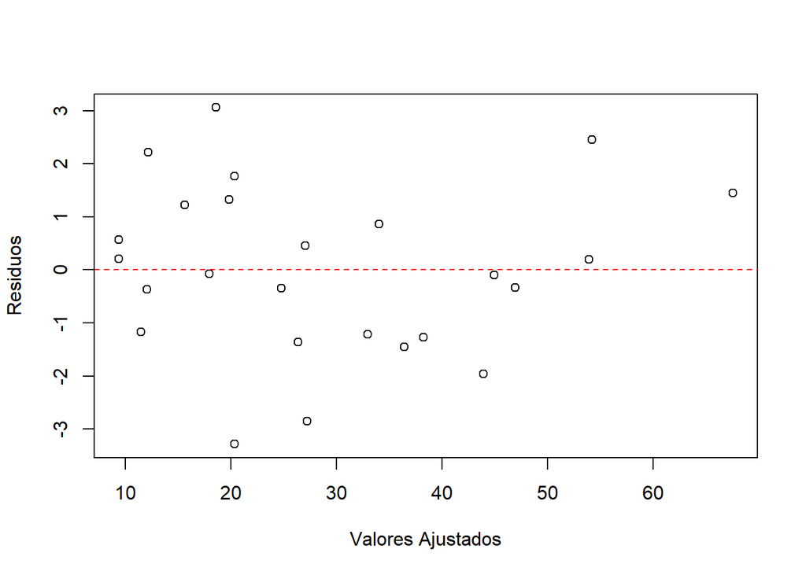

```r
plot(ajustados, residuos, xlab = "Valores Ajustados", ylab = "Residuos")
abline(h = 0, col = "red", lty = 2)
```

```r
bptest(modelo_r)
```

```
##
##  studentized Breusch-Pagan test
##
## data:  modelo_r
## BP = 4.0079, df = 4, p-value = 0.4049
```

```r
dwtest(modelo_r)
```

```
##
##  Durbin-Watson test
##
## data:  modelo_r
## DW = 1.5722, p-value = 0.1193
## alternative hypothesis: true autocorrelation is greater than 0
```

### Normalidad de los residuos

Mediante la prueba de Shapiro-Wilk, se observa como el p-value es mayor a 0.05. No se rechaza la hipótesis nula; los residuos distribuyen de manera normal.

### Verificación de media cero

Se observa como la media de los residuos es prácticamente 0 (1.64e-16)

### Homocedasticidad

Se realizó la prueba de Breusch-Pagan con $p\text{-valor} = 0.4049 > 0.05$. Se satisface el supuesto de varianza constante de los errores.

## Declaratoria de uso de IA durante el desarrollo del trabajo

Se utilizó IA:

1. Herramienta: Gemini
2. Uso realizado: Ayuda en el código a lo largo de la tarea, mayormente en gráficos, en el VIF y en la validación de supuestos.
3. Secciones donde se utilizó: Incisos 1, 2, 4 y 5.
4. Validación realizada por los estudiantes: Se verificó, corrió y depuró todo el script de R, así como también analizaron todos los resultados arrojados para validar que todo estuviera correcto y en orden.
5. Confirmo de que se revisó, verificó y que se asume la responsabilidad del contenido final entregado.